# ECON 4341W Data Example

Yiyuan He

2026-09-15

```r
knitr::opts_chunk$set(echo = TRUE)
library(ggplot2)
library(ipumsr)
library(haven)
library(spatstat)
library(tidyverse)
```

# 1 Objective

This file shows that given a dataset that might interest you, what you can explore to understand whether the dataset fits your data. In this file, we mostly follow the practice suggested by “Data: How to Understand Them (Detailed)” section in the slides.

For the example, we use ACS data from 2003 to 2015.

```r
ddi <- read_ipums_ddi("usa_00019.xml")
acs <- read_ipums_micro(ddi)
```

```
## Use of data from IPUMS USA is subject to conditions including that users should cite the data appropriately. Use command `ipums_conditions()` for more details.
```

Before starting on further analysis, it would be nice for us to stop and ponder a little:

```r
acs <- acs %>%
  filter(AGE >= 16 & AGE <= 65)
```

2. **Are there missing observations in your data?** I am not leading you step by step here, since this requires a back-and-forth between checking the data by yourself and reading the codebook or the documentation of the data.
   - For instance, we might want to check a variable, let’s say, marital status. It might be the case that we check in R (or any of your favorite data analysis tool) that there are no missing values. Then, you might want to go back to the codebook, and notice that observations with value equal to 9 are actually missing values. Then you clean your data based on this information…

# 2 Basic Information of the data

**1. What is the unit of observation in your data?**

**Solution.** The units of observation for the American Community Survey (ACS) are individual persons (living in housing units or group quarters) and housing units (whether occupied or vacant)

For what we concern about, we should focus on individual-level data.

**2. How many observations are in your dataset?**

```r
cat("There are", nrow(acs), "observations in our data.\n")
```

```
## There are 23386479 observations in our data.
```

```r
count(acs, YEAR)
```

| YEAR | n |
| --- | --- |
| 2003 | 773832 |
| 2004 | 772304 |
| 2005 | 1862906 |
| 2006 | 1938821 |
| 2007 | 1956750 |
| 2008 | 1959056 |
| 2009 | 1975366 |
| 2010 | 1994615 |
| 2011 | 2029986 |
| 2012 | 2028818 |

[output cut: 3 more lines]

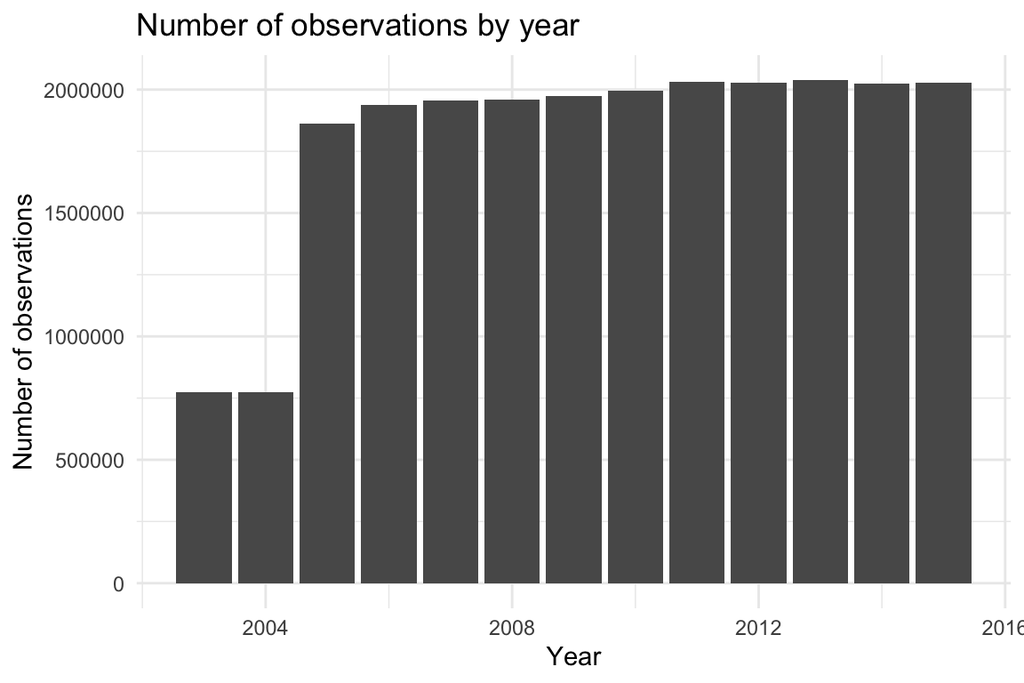

```r
count(acs, YEAR) %>%
  ggplot(aes(x = YEAR, y = n)) +
  geom_col() +
  labs(
    x = "Year",
    y = "Number of observations",
    title = "Number of observations by year"
  ) +
  theme_minimal()
```

**3. How many variables are in your dataset?**

```r
cat("There are", length(acs),"variables in my dataset. Details of all variables are shown in the following table.\n")
```

```
## There are 24 variables in my dataset. Details of all variables are shown in the following table.
```

```r
# Check the details of data using the package
ipums_var_info(ddi)
```

| var_name | var_label | var_desc | val_labels | code_instr | start | end | imp_decim | var_type | rectypes |
| --- | --- | --- | --- | --- | --- | --- | --- | --- | --- |
| YEAR | Census year | YEAR reports the four-digit year when the household was enumerated or included in the census, the ACS, and the PRCS.\n\nFor the multi-year ACS/PRCS samples, YEAR indicates the last year of data includ… |  | NA | 1 | 4 | 0 | integer | NA |
| SAMPLE | IPUMS sample identifier | SAMPLE identifies the IPUMS sample from which the case is drawn. Each sample receives a unique 6-digit code. The codes are structured as follows:\n\nThe first four digits are the year of the census/su… |  | NA | 5 | 10 | 0 | integer | NA |
| SERIAL | Household serial number | SERIAL is an identifying number unique to each household record in a given sample. All person records are assigned the same serial number as the household record that they follow. (Person records also… |  | SERIAL is an 8-digit numeric variable which assigns a unique identification number to each household record in a given sample (See PERNUM for the analogous person record identifier). A combination of … | 11 | 18 | 0 | numeric | NA |
| CBSERIAL | Original Census Bureau household serial number | CBSERIAL is the unique, original identification number assigned to each household record in a given sample by the Census Bureau. All person records are assigned the same serial number as the household… |  | CBSERIAL is an 8-digit numeric variable which assigns a unique identification number to each household record in a given sample (See CBPERNUM for the analogous person record identifier). CBSERIAL spec… | 19 | 31 | 0 | numeric | NA |
| HHWT | Household weight | HHWT indicates how many households in the U.S. population are represented by a given household in an IPUMS sample. \n\nIt is generally a good idea to use HHWT when conducting a household-level analysi… |  | HHWT is a 6-digit numeric variable which indicates how many households in the U.S. population are represented by a given household in an IPUMS sample and has two implied decimals. For example, a HHWT … | 32 | 41 | 2 | numeric | NA |
| CLUSTER | Household cluster for variance estimation | CLUSTER is designed for use with STRATA in Taylor series linear approximation for correction of complex sample design characteristics. See the STRATA variable description for more details. |  | CLUSTER is an 11-digit numeric variable designed for use with STRATA in Taylor series linear approximation for correction of complex sample design characteristics (See the Description of STRATA for mo… | 42 | 54 | 0 | numeric | NA |
| STATEICP | State (ICPSR code) | STATEICP identifies the state in which the housing unit was located, using the coding scheme developed by the Inter-University Consortium for Political and Social Research (ICPSR). The ICPSR scheme or… |  | NA | 55 | 56 | 0 | integer | NA |
| STRATA | Household strata for variance estimation | STRATA is designed for use with CLUSTER in Taylor series linear approximation for correction of complex sample design characteristics.\n\nWhile appropriate use of the sampling weights PERWT and HHWT a… |  | STRATA is a 12-digit numeric variable designed for use with CLUSTER in Taylor series linear approximation for correction of complex sample design characteristics. While appropriate use of the sampling… | 57 | 68 | 0 | numeric | NA |
| GQ | Group quarters status | GQ classifies all housing units as falling into one of three main categories: households, group quarters, or vacant units. It also identifies fragmentary sample units for 1850-1930 (see below). In all… |  | NA | 69 | 69 | 0 | integer | NA |
| PERNUM | Person number in sample unit | PERNUM numbers all persons within each household consecutively in the order in which they appear on the original census or survey form. When combined with SAMPLE and SERIAL, PERNUM uniquely identifies… |  | PERNUM is a 4-digit numeric variable which numbers all persons within each household consecutively in the order in which they appear on the original census or survey form. PERNUM specific variable cod… | 70 | 73 | 0 | numeric | NA |

[output cut: 14 more lines]

# 3 Description of Interested Variables

**4. What is the single most important variable that will be on the left-hand-side of your regression?**

**Solution.** Recall that our example investigates the effect of the Great Recession (2007-2009) on individual’s marital status and marital sorting. The second concept requires more treatment on data, so for demonstration purpose, here we ignore the second part, and focus on the first part.

Therefore, the single most important variable that will be on the left-hand-side of our regression is marital status, or the `MARST` variable in our data.

**5. What is the key right-hand-side variable (or variables) most important for investigating your hypothesis?**

**Solution.** Our key right-hand-side variable is the state-level unemployment percentage rate change during the recession period. Specifically, we define it as

$$\% \Delta Unemployment_s =
\frac{Unemployment_{s,2010} -
Unemployment_{s,2006}}{Unemployment_{s,2006}}.$$

I assure you that I construct this variable by myself from this data we are using here, so you should know that you are not *that* constrained by the dataset you have on your hand…

However, I don’t want to bother you too much about how to this, at least right now. So, let us pretend that we have the variable already in our dataset.

```r
employ <- read_dta("employment_treatment_state.dta")

acs <- acs %>%
  left_join(employ, by = c("STATEICP" = "stateicp"))
```

**6. What other variables do you plan to put on the right-hand-side in order to control for confounding influences?**

**Solution.** Age and education level of individuals matter for their marriage decision. Also, state law variation and the general trend of marriage can matter as well.

# 4 Summary Statistics of Interested Variables

**7. What is the mean of your left-hand-side variable? What is the range of this variable?**

**Solution.** We first investigate the variable `MARST`. Since our variable here is categorical rather than continuous, we check its definition for each categories and its overall distribution, instead of calculating the mean.

Notice that we are dealing with survey data, so it is important for us to consider the survey weight during calculation. For now, we are doing a preliminary data check, so I ignore this part.

```r
# label
cat("The label of `MARST` is shown as follows:\n")
```

```
## The label of `MARST` is shown as follows:
```

```r
attr(acs$MARST, "labels")
```

```
## Married, spouse present  Married, spouse absent               Separated
##                       1                       2                       3
##                Divorced                 Widowed    Never married/single
##                       4                       5                       6
##          Blank, missing
##                       9
```

```r
cat("The distribution of `MARST` is shown as follows:")
```

```
## The distribution of `MARST` is shown as follows:
```

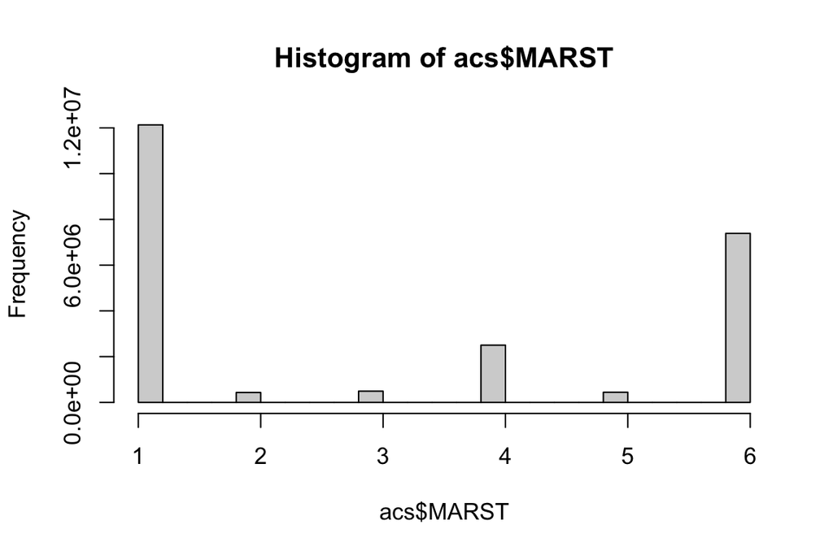

```r
hist(acs$MARST)
```

As we have an initial idea on this variable, it seeems to be natural for us to start wondering: how would this distribution differ across age group? How about education group?

Also, it seems that some dimensions contain little observation. In response to this, do we want to reduce the dimensions of the variable? Shall we consider convert this variable into a binary variable, such as “whether people are married”?

As an example, we construct this “married” variable as follows:

1. it equals to 1 if people are married (`MARST` == 1 or `MARST` == 2), and
2. it equals to 0 otherwise.

```r
acs <- acs %>%
  mutate(
    married = case_when(
      MARST == 1 ~ 1,
      MARST == 2 ~ 1,
      TRUE ~ 0
    )
  )
```

We can further check the mean and the distribution of the new variables. Notice that since our variable now becomes binary, its mean actually has an interpretation: it means the percentage of married people over the entire population.

```r
cat("The mean of `married` is", mean(acs$married))
```

```
## The mean of `married` is 0.5372772
```

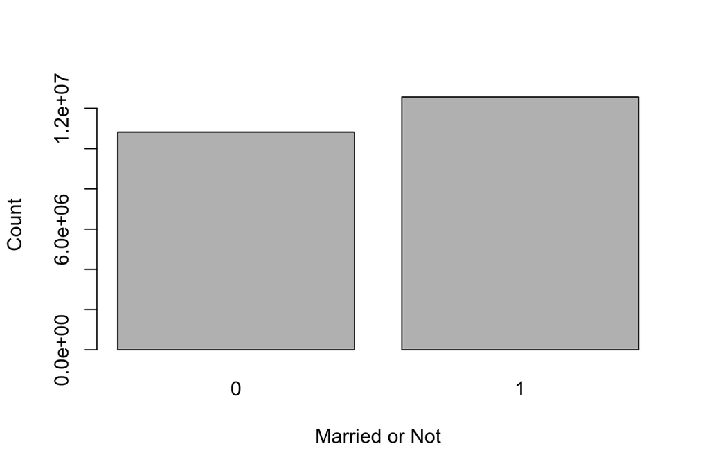

```r
barplot(
  table(acs$married),
  xlab = "Married or Not",
  ylab = "Count"
)
```

**8. Give the same information for the right-hand-side variables.**

**Solution.**

For Questions 8 and 9, I only show the result for my key right-hand-side variable as an example. For your practice, you might want to do these exercises for all right-hand-side variables to understand more about your data.

The summary statistics of our right-hand-side variable (i.e., the state-level percentage change of unemployment rate) is shown as follows.

```r
summary(acs$per_change)
```

```
##    Min. 1st Qu.  Median    Mean 3rd Qu.    Max.
##   2.224  56.953  65.785  76.116  98.337 179.667
```

**9. What is the correlation between your left-hand-side variable and the key right-hand-side variable?**

```r
cat("The correlation between the left-hand-side variable and the key right-hand-side variable is",
    round(cor(acs$married, acs$per_change), 4)
    )
```

```
## The correlation between the left-hand-side variable and the key right-hand-side variable is -0.0141
```